# 民主政治：概念與界定

師大公領系教授 黃信豪

2020/9/17

# Topics

**一、比較政體分類：界定民主制度**  
**二、民主政治的內涵**  
**三、民主政體真的「比較好」嗎？**

# 一、比較政體分類：界定民主制度

### （一）政體(form of government)的類型：

- 意義：一國政治、統治形態 $\Rightarrow$ 國家政治體系運作的形式。
- 如何分類？Burgess(1994)的討論：

#### 1.主權機關與政府機關是否「有區別」？

- 直接政府、間接政府：主權機關 **=** or **=/=** 政府機關。

#### 2.國家元首的產生方式：是否為「君主制」？「君主」是否為實質領導人？

- 君主專制、君主立憲制、民選首長。
- 民主？

#### 3.行政與立法部門關係：權力分立or融合？

- 內閣制、總統制（半總統制$\backslash$雙首長制）

#### 4.（各層級）政府機關的職權集散？

- 單一制、聯邦制。

# （二）如何比較民主運作？制度條件？

- **自由之家(Freedom house)**https://freedomhouse.org/：1940年創立，每年對世界各獨立國家、地區的政治權利(Political Rights) 與公民自由(Civil Liberties) 分別進行調查、評分(1-7分, 最自由-最不自由)。
- 評分條件：政治權利（選舉過程、政治多元與參與、政府運作）、公民自由（表達與信仰自由、集會結社權利、法治） https://freedomhouse.org/reports/freedom-world/freedom-world-research-methodology
- 加總區分為三級距：「自由」（Free）、「部分自由」（Partly Free）與「不自由」（Not Free）三個等級。
- 年度報告（Full Report PDF）：https://freedomhouse.org/sites/default/files/2020-02/FIW_2020_REPORT_BOOKLET_Final.pdf
- **Economist：EIU democracy index**： https://en.wikipedia.org/wiki/Democracy_Index#Classification_definitions

### 年度報告一些圖表

- 民主在倒退(14 years)

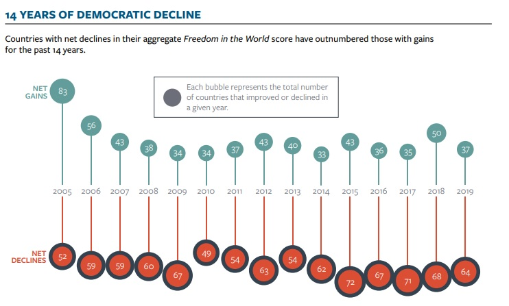

- 各類別國家的變動(1989-2019)

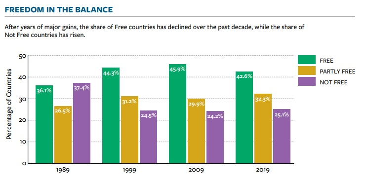

- 各指標的變動(14 years)：按地區

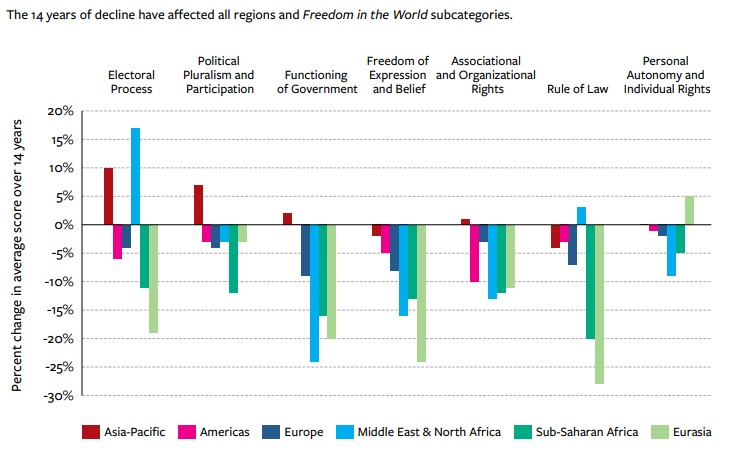

- 人口與國家數量

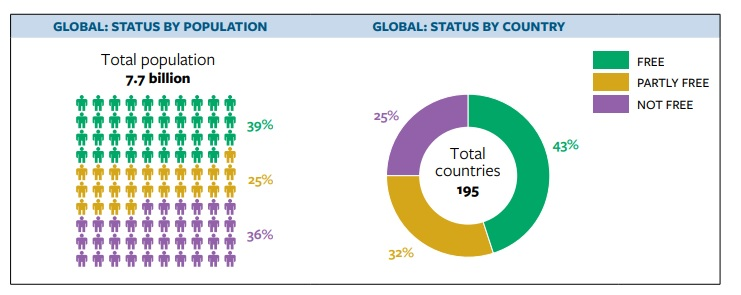

- 人口與國家數量:美洲

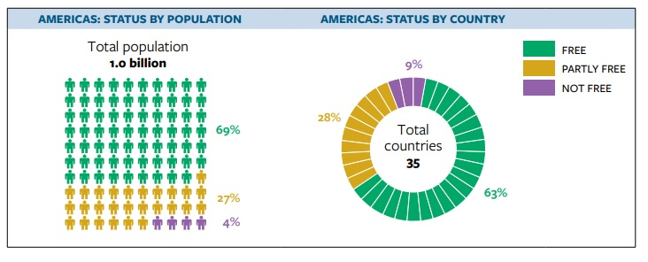

- 人口與國家數量:亞洲與大洋洲

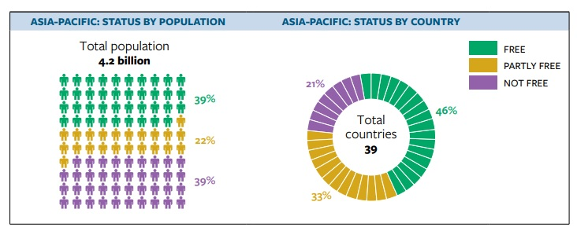

- 人口與國家數量:歐亞大陸

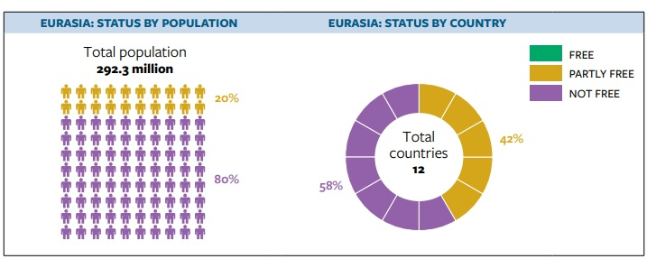

- 人口與國家數量:歐洲

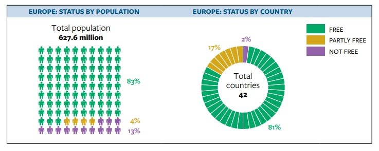

- 人口與國家數量:中東與北非

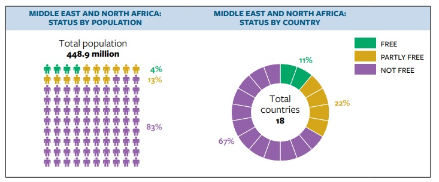

- 人口與國家數量:非洲撒哈拉地區

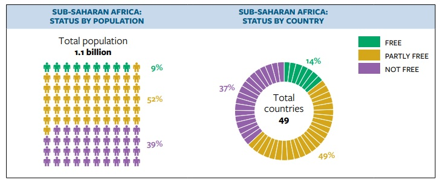

- **Q：哪些地區民主發展最好？哪些地區型態最多樣？哪些地區民主發展最差？**

# （三）民主制度要件的「最小定義」

- 最小定義(minimal definition)：能符合最多國家/個案的標準。
- 界定當代「自由民主體制」(liberal democracy)(LeDuc et al. 2006), 「專制—民主」光譜
  - Step1: Is the territory **an independent national state**?
    - 原則：具國際法人地位，受其他國家廣泛認可？
    - territories(47) vs. independent national states (199)
  - Step2: Does the national-state hold **direct elections**?
    - 原則：國家的重要主體(bodies)是否由人民選出？還是任命、繼承？週期性的直接選舉。
    - 專制獨裁政體autocracies(6) vs.選舉式政體electoral regimes (185)
    - 問題：無法區別選舉的**競爭程度**。
  - Step3: Do the elections meet international standards for **multi-party competition**?
    - 原則：選舉是否「多黨（人）」競爭？意義
      - 1.參政權是否普及？2.多黨（人）競爭的意義。
  - Step4: Does the regime respect full **political rights and civil liberties**?
    - 原則：完整的公民自由、政治權利保障。
    - 選舉式民主政體Electoral democracies (32) vs.自由民主政體liberal democracy (88)
  - Robert Dahl(1989)的**多元政體（polyarchy）**：(1)公開競爭(public contestation)；(2)參與(participation)，廣泛包容，每個公民都獲得權利保障。

# 二、民主政治的內涵

- 民主政體：一個依據**主權在民**、**政治平等**、**人民諮商**與**多數決原則**所組成的政府形式(Ranney 2001:95)。
  - **1.主權在民(popular sovereignty)**：主權屬於全體公民，政府統治建立在人民同意上（授權），反之亦然。
    - (1)對人民負責；(2)有意義的選舉；(3)人民有持異議與不服從的權力。
    - Debate(1)：代議士的角色？
    - Debate(2)：罷免門檻？
    - Debate(3)：憲政空窗期 $\Rightarrow$ 總統提前下台？
  - **2.政治平等(political equality)**：公民有平等的機會參政。
    - 選舉權：票票等值；被選舉權：平等表達觀點、爭取政治職位。
    - Debate(1)：選舉制度（單一選區兩票制）$\Rightarrow$ 票票不等值？
    - Debate(2)：下修投票年齡？
    - Debate(3)：不在籍投票？
    - Debate(4)：選舉的保證金制度？公費選舉？
  - **3.人民諮商(popular consultation)**：官員與代議士決策必須諮商人民意見– 體系有某種「機制」，使決策者瞭解人民期望，成為其決策依循。
    - Debate(1)： iVoting?
    - Debate(2)：參與式預算的試驗？
  - **4.多數決(majority rule)**:當歧見發生時，用多數決來決定 。
    - 政府應該以多數人為意見；少數否決權？
    - Debate(1)：多數決可以決定的範圍？

# 三、民主政體真的比較「好」嗎？

• 投書紐時 前英相布萊爾：民主政治已死？  
• http://www.guancha.cn/tonyblair/2014_12_27_304571.shtml  
• 民主選舉真的民主嗎？  
• http://cnpolitics.org/2017/02/democracy-6/  
• http://cnpolitics.org/2017/02/democracy-elections/  
• 民主真的帶來美好生活嗎？  
• https://whogovernstw.org/2019/01/28/yitingwang6/

- 邱吉爾：「民主是很糟糕的政府型態，但比其他嘗試過的政府型態來得好。」（Democracy is the worst form of government except all the others that have been tried）
- 與其說較「好」，不如說最有**「適應性」(adaptive)** 。從**政府形式**來理解：
  - 1.是確保「正當性」的程序安排：政府運作符合多數人偏好。
  - 2.正當性的自我更新(renew mechanism for political legitimacy)。
  - 其他優點：(1)體制上的寬容；(2)培養政治德性(civic virtue)；(3)溫和、不激化。
- 民主比較沒有效率？
  - 1.責任政治未落實 $\Rightarrow$ 在各種政體形式中，民主是唯一「可責的」(accountable)
  - 2.官僚獨立性。
  - 「黨意」大於「民意」？
- 民主政治運作取決於民眾的「素質」，獨裁有時候更好？
  - 1.政治資訊的多樣化：大眾傳媒的角色。
  - 2.個人所關注的議題面向、數量、強度不同：「素質」低不代表民眾不關心公共議題，是關心的議題面向不同。
  - 3.是選民集體選擇：集體選擇勝過一人抉擇。